# Assessment Pepkor Data & Analytics

### Question 1

*Please see attached list of birthdays for a certain company (birthdays.txt). Do the values supplied make sense? Why/why not? Are there any interesting things in the data? If so, what are they and how do you think they happened?*

We start by importing the necessary Python libraries

```python
import calendar
import datetime
import pandas as pd
import numpy as np
from pathlib import Path
import matplotlib.pyplot as plt
import matplotlib.dates as mdates
import sqlite3
import csv
%matplotlib inline
```

Then we load in the data and begin our investigation

```python
p = Path.home() / 'Documents' / 'PepkorTests'
bdays = pd.read_csv(p / 'birthdays.txt')
# convert date columns to date format
bdays['date of birth'] = pd.to_datetime(bdays['date of birth'].str.replace('_', '-'))
bdays['Date'] = pd.to_datetime(bdays['Date'])
```

```python
bdays['Date'].equals(bdays['date of birth'])
```

```
True
```

The `Date` column and `date of birth` column are equal, so we drop one

```python
bdays.drop(columns='Date', inplace=True)
```

One unusual thing is that there are roughly 62 percent of people older than 65. This suggests that this is historic company data rather than more recent data.

```python
retirement = datetime.datetime.now().year - 65
(bdays['date of birth'].dt.year < retirement).sum() / len(bdays)
```

```
0.6193734487153686
```

Next we check the plot of birth months. February has the fewest number of people

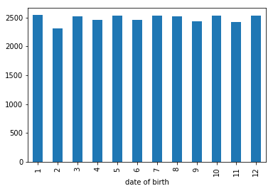

```python
bdays.groupby([bdays['date of birth'].dt.month]).count()['number of people'].plot(kind='bar')
plt.show()
```

Next we plot the birth years. Between 1910 and 1982, the number of birthdays for the year was 365, suggesting the company had roughly the same number of employees in that period.

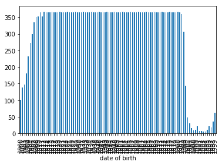

```python
bdays.groupby([bdays['date of birth'].dt.year]).count()['number of people'].plot(kind='bar')
plt.show()
```

Next we check the distribution of people with the same birthday, both with a histogram and boxplot. There is a positive skew in the distribution.

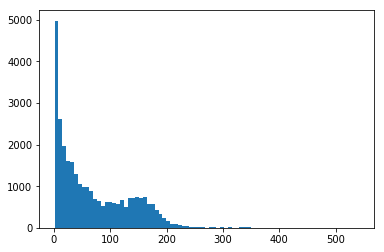

```python
_, bins = np.histogram(bdays['number of people'], bins='fd')
plt.hist(bdays['number of people'], bins=bins)
plt.show()
```

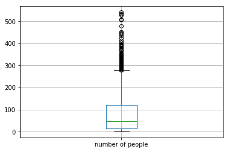

```python
plt.cla(); plt.clf()
bdays.boxplot('number of people')
plt.show()
```

An interesting thing with the outliers is that the day and month are the same in 193 of 295 (65 %) cases.

There may have been something wrong with the capturing of data.

```python
outliers = bdays[bdays['number of people'] > int(bdays.quantile(q=0.99))]
(outliers['date of birth'].dt.day == outliers['date of birth'].dt.month).sum()
```

```
193
```

## Question 2

The solution is to take two groups of 3 balls and one group of 2. On the first weigh, put 3 balls on each side. If the scale balances, the heavier ball is in the remaining group of 2. In the second weigh, put one ball on each side. You will then see the heavier ball.

If the scale doesn't balance after the first weigh, it means that you can discard the lighter group. You are now left with 3 balls. On the second weigh, put the one ball on each side. If the scale balances, you know it is the third ball that wasn't weighed. Otherwise you will identify the ball.

## Question 3

*This question is meant to test basic SQL skills and data manipulation. Please see attached tables of data (survey_data.txt and survey_keys.txt). The data represents results of a survey asking people their age, gender and education. See example below.*

| id | ageband | gender | education |  |
| --- | --- | --- | --- | --- |
| 1 | 3 | 6 | 7 |  |
| 2 | 1 | 6 | 7 |  |
| 3 | 2 | 5 | 7 |  |
| 4 | 3 | 6 | 10 |  |
| 5 | 2 | 5 | 10 |  |
| 6 | 3 | 6 | 9 |  |

| lookup | Descr |
| --- | --- |
| 1 | 20-29 |
| 2 | 30-39 |
| 3 | 40-49 |
| 4 | 50-59 |
| 5 | male |
| 6 | female |

*Write a SQL statement that produces the following summary for ageband:*

| ageband | count | id's |
| --- | --- | --- |
| 20-29 | 18 | 2,11,36,42, ... |
| 30-39 | 24 | 3,5,10,12, ... |
| 40-49 | 26 | 1,4,6,9,13, ... |
| 50-59 | 32 | 7,8,15,16, ... |

*Similarly give the SQL statement for gender and education. How would you alter your solution so that if there were many more questions, you wouldn’t have to change much?*

Start by setting up a `sqlite` db in Python. The schema is defined as

```
CREATE TABLE IF NOT EXISTS survey_data (
id int,
ageband int,
gender int,
education int
);

CREATE TABLE IF NOT EXISTS survey_key (
lookup int,
descr text
);
```

```python
conn = sqlite3.connect('my.db')
c = conn.cursor()
with open(p / 'sql_schema.sql') as f:
    schema = f.read()
c.executescript(schema)
conn.commit()
```

Then populate the tables. Define a function that will make read in the text data

```python
def populate_table(data: str):
    csv_reader = csv.reader(open(data), delimiter='|',skipinitialspace=True)
    next(csv_reader)
    return tuple(line for line in csv_reader)
```

```python
to_survey_data = populate_table(p /'survey_data.txt')
c.executemany('INSERT INTO survey_data VALUES (?, ?, ?, ?);', to_survey_data)
```

```
<sqlite3.Cursor at 0x268ccf861f0>
```

```python
to_survey_key = populate_table(p / 'survey_key.txt')
c.executemany('INSERT INTO survey_key VALUES (?, ?);', to_survey_key)
conn.commit()
```

We check that all went as expected

```python
survey_data = pd.read_sql('SELECT * from survey_data limit 5', conn)
survey_key = pd.read_sql('SELECT * from survey_key limit 5', conn)
print(survey_data)
print(survey_key)
```

```
   id  ageband  gender  education
0   1        3       6          7
1   2        1       6          7
2   3        2       5          7
3   4        3       6         10
4   5        2       5         10
   lookup  descr
0       1  20-29
1       2  30-39
2       3  40-49
3       4  50-59
4       5   male
```

To calculate the ageband summary, we use the following query

```python
query = """
SELECT descr as ageband, count(*), group_concat(id, ',') from
(SELECT * FROM survey_data
LEFT JOIN survey_key ON survey_data.ageband = survey_key.lookup)
group by ageband"""

df = pd.read_sql(query, conn)
print(df)
```

```
  ageband  count(*)                              group_concat(id, ',')
0   20-29        72  2,2,11,11,36,36,42,42,44,44,45,45,51,51,52,52,...
1   30-39        96  3,3,5,5,10,10,12,12,19,19,25,25,26,26,27,27,29...
2   40-49       104  1,1,4,4,6,6,9,9,13,13,14,14,20,20,24,24,37,37,...
3   50-59       128  7,7,8,8,15,15,16,16,17,17,18,18,21,21,22,22,23...
```

For gender we use

```python
query_gender = """
SELECT descr as gender, count(*), group_concat(id, ',') from
(SELECT * FROM survey_data
LEFT JOIN survey_key ON survey_data.gender = survey_key.lookup)
group by gender"""
df_gender = pd.read_sql(query_gender, conn)
print(df_gender)
```

```
   gender  count(*)                              group_concat(id, ',')
0    male       184  3,3,5,5,7,7,11,11,14,14,16,16,17,17,18,18,22,2...
1  female       216  1,1,2,2,4,4,6,6,8,8,9,9,10,10,12,12,13,13,15,1...
```

And education we use

```python
query_education = """
SELECT descr as education, count(*), group_concat(id, ',') from
(SELECT * FROM survey_data
LEFT JOIN survey_key ON survey_data.education = survey_key.lookup)
group by education """
df_education = pd.read_sql(query_education, conn)
print(df_education)
```

```
   education  count(*)                              group_concat(id, ',')
0       none        92  1,1,2,2,3,3,13,13,14,14,17,17,36,36,38,38,40,4...
1    primary        96  11,11,12,12,16,16,20,20,21,21,22,22,23,23,25,2...
2  secondary       112  6,6,7,7,8,8,9,9,15,15,24,24,26,26,28,28,31,31,...
3   tertiary       100  4,4,5,5,10,10,18,18,19,19,27,27,29,29,39,39,41...
```

To generalize this query, it would be helpful to define a function that takes the column of interest as a parameter. Something such as

```
CREATE FUNCTION survey_counts (@column int)
RETURNS TABLE
AS
RETURN
(
SELECT descr as @column, count(*), group_concat(id, ',') from
(SELECT * FROM survey_data
LEFT JOIN survey_key ON survey_data.@column = survey_key.lookup)
group by @column)
```

## Question 4

*Write a python function that take in an input, a year, and outputs whether the year is a leap year. e.g.*

```
>> def is_leap_year(year):
    #some processing

>> is_leap_year(1900)
>> False
```

*A leap year is defined by 3 criteria:*

- The year can be evenly divided by 4, is a leap year, unless:
- The year can be evenly divided by 100, it is NOT a leap year, unless:
- The year is also evenly divisible by 400. Then it is a leap year.

*What tests would you perform when evaluating your function?*

```python
def is_leap_year(year: int):
    assert isinstance(year, int) or isinstance(year, float), 'Must be numeric'
    if year % 4 != 0:
        return False
    elif year % 100 !=0:
        return True
    elif year % 400 !=0:
        return False
    else:
        return True
```

The major test would be comparing my function with the built in function in the `calendar` library

```python
for year in range(1500, 2000):
    if not (calendar.isleap(year) == is_leap_year(year)):
        raise Exception('Disagreement for year {year}')
```

## Question 5

*Validation of South African ID numbers is a very important task. The check can be found here https://www.westerncape.gov.za/general-publication/decoding-your-south-african-id-number-0 . Write a SQL statement that does the various checks OR write a Python function that does the required checks. You may use the number in the above website to check. What do you think would be the possible advantages/disadvantages of using your chosen language over the other? How would you check for a passport number?*

we define a function that checks

- the length of the input is 13 digits
- That the first 6 digits are a valid date
- That the 11th digit is either 0 or 1
- that the 12th digit is an 8
- that the 13th digit is calculated by Luhn's Algorithm

```python
def sa_id(id_number: int):
    str_id = str(id_number)
    assert len(str_id) == 13, 'ID is incorrect number of digits'
    # Check that date is valid. datetime constructor will throw an error if invalid
    datetime.datetime(int(str_id[:2]), int(str_id[2:4]), int(str_id[4:6]))
    # Check citizenship
    assert str_id[10] == '0' or str_id[10] == '1', 'Invalid Citizenship Code'
    # Check for the number 8
    assert str_id[11] == '8', '12th digit must be 8'
    # Checksum using Luhn's algorithm
    # Extract digis
    digits = [int(d) for d in str_id]
    odd_digits = digits[-1::-2]
    even_digits = digits[-2::-2]
    checksum = 0
    checksum += sum(odd_digits)
    for d in even_digits:
        # Double each digit and add the digits of the result
        checksum += sum([int(i) for i in str(d*2)])
    return checksum % 10 == 0
```

We check this with a few sample ID numbers

```python
id_list = [8306045800086, 8306044800087, 7302015800082]
for id_no in id_list:
    print(sa_id(id_no))

sa_id(7302015800682)
```

```
True
True
True
```

```
---------------------------------------------------------------------------
AssertionError                            Traceback (most recent call last)
<ipython-input-22-6c6d380cd568> in <module>
      3     print(sa_id(id_no))
      4
----> 5 sa_id(7302015800682)

<ipython-input-21-d2bb156a0d65> in sa_id(id_number)
      5     datetime.datetime(int(str_id[:2]), int(str_id[2:4]), int(str_id[4:6]))
      6     # Check citizenship
----> 7     assert str_id[10] == '0' or str_id[10] == '1', 'Invalid Citizenship Code'
      8     # Check for the number 8
      9     assert str_id[11] == '8', '12th digit must be 8'

AssertionError: Invalid Citizenship Code
```

For passport validation, the numbering format is a letter followed by a 8 digits (http://www.e4.co.za/downloads/passport.pdf).

```python
def sa_passport(id_number: str):
    str_id = str(id_number)
    assert len(str_id) == 9, 'Passport number must be 9 digits'
    assert not str_id[0].isdigit(), 'First element must be a character'
    # Check that the remaining 8 elements are numbers
    assert str_id[1:].isdigit(), 'The remaining 8 elements must be digits'
    return True
```

Using Python would make the code for validating the ID numbers more readable. Whereas SQL syntax would be longer, but better for large scale validation.